# Red Wine Analysis by Chad Hall

> This data set contains information about the various elements of red wine, along with its quality.

# Univariate Plots Section

```
## [1] 1599   14
```

```
## 'data.frame':    1599 obs. of  14 variables:
##  $ X                   : int  1 2 3 4 5 6 7 8 9 10 ...
##  $ fixed.acidity       : num  7.4 7.8 7.8 11.2 7.4 7.4 7.9 7.3 7.8 7.5 ...
##  $ volatile.acidity    : num  0.7 0.88 0.76 0.28 0.7 0.66 0.6 0.65 0.58 0.5 ...
##  $ citric.acid         : num  0 0 0.04 0.56 0 0 0.06 0 0.02 0.36 ...
##  $ residual.sugar      : num  1.9 2.6 2.3 1.9 1.9 1.8 1.6 1.2 2 6.1 ...
##  $ chlorides           : num  0.076 0.098 0.092 0.075 0.076 0.075 0.069 0.065 0.073 0.071 ...
##  $ free.sulfur.dioxide : num  11 25 15 17 11 13 15 15 9 17 ...
##  $ total.sulfur.dioxide: num  34 67 54 60 34 40 59 21 18 102 ...
##  $ density             : num  0.998 0.997 0.997 0.998 0.998 ...
##  $ pH                  : num  3.51 3.2 3.26 3.16 3.51 3.51 3.3 3.39 3.36 3.35 ...
##  $ sulphates           : num  0.56 0.68 0.65 0.58 0.56 0.56 0.46 0.47 0.57 0.8 ...
##  $ alcohol             : num  9.4 9.8 9.8 9.8 9.4 9.4 9.4 10 9.5 10.5 ...
##  $ quality             : int  5 5 5 6 5 5 5 7 7 5 ...
##  $ new_quality         : Factor w/ 6 levels "3","4","5","6",..: 3 3 3 4 3 3 3 5 5 3 ...
```

```
##        X          fixed.acidity   volatile.acidity  citric.acid
##  Min.   :   1.0   Min.   : 4.60   Min.   :0.1200   Min.   :0.000
##  1st Qu.: 400.5   1st Qu.: 7.10   1st Qu.:0.3900   1st Qu.:0.090
##  Median : 800.0   Median : 7.90   Median :0.5200   Median :0.260
##  Mean   : 800.0   Mean   : 8.32   Mean   :0.5278   Mean   :0.271
##  3rd Qu.:1199.5   3rd Qu.: 9.20   3rd Qu.:0.6400   3rd Qu.:0.420
##  Max.   :1599.0   Max.   :15.90   Max.   :1.5800   Max.   :1.000
##  residual.sugar     chlorides       free.sulfur.dioxide
##  Min.   : 0.900   Min.   :0.01200   Min.   : 1.00
##  1st Qu.: 1.900   1st Qu.:0.07000   1st Qu.: 7.00
##  Median : 2.200   Median :0.07900   Median :14.00
##  Mean   : 2.539   Mean   :0.08747   Mean   :15.87
##  3rd Qu.: 2.600   3rd Qu.:0.09000   3rd Qu.:21.00
##  Max.   :15.500   Max.   :0.61100   Max.   :72.00
##  total.sulfur.dioxide    density             pH          sulphates
##  Min.   :  6.00       Min.   :0.9901   Min.   :2.740   Min.   :0.3300
##  1st Qu.: 22.00       1st Qu.:0.9956   1st Qu.:3.210   1st Qu.:0.5500
##  Median : 38.00       Median :0.9968   Median :3.310   Median :0.6200
##  Mean   : 46.47       Mean   :0.9967   Mean   :3.311   Mean   :0.6581
##  3rd Qu.: 62.00       3rd Qu.:0.9978   3rd Qu.:3.400   3rd Qu.:0.7300
##  Max.   :289.00       Max.   :1.0037   Max.   :4.010   Max.   :2.0000
##     alcohol         quality      new_quality
##  Min.   : 8.40   Min.   :3.000   3: 10
##  1st Qu.: 9.50   1st Qu.:5.000   4: 53
##  Median :10.20   Median :6.000   5:681
##  Mean   :10.42   Mean   :5.636   6:638
##  3rd Qu.:11.10   3rd Qu.:6.000   7:199
##  Max.   :14.90   Max.   :8.000   8: 18
```

- The dataset contains 14 variables.
- The first variable, x, is a unique identifier and sequenced count. I will not be including it in any of the analysis.
- I have added a new variable, new_quality, which is factored copy of the quality varaible. This will assist in some analysis later.
- There are almost 1600 observations.

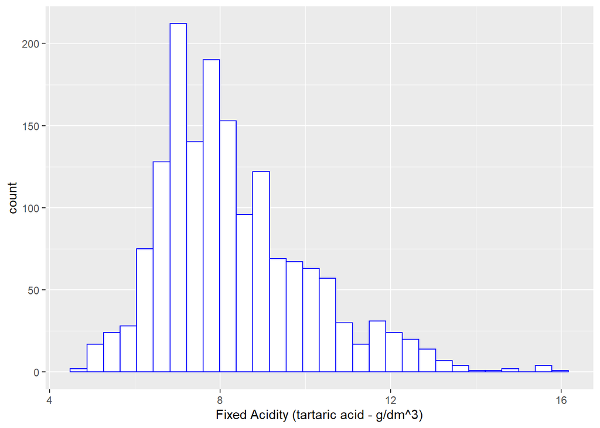

Most of the observations are around 6-11. There are a very low ammount of observations that are between 14-16. The lowest count of observations lies around 14. Later, I may want to see if this variable has any correlation to other acidity levels or pH level.

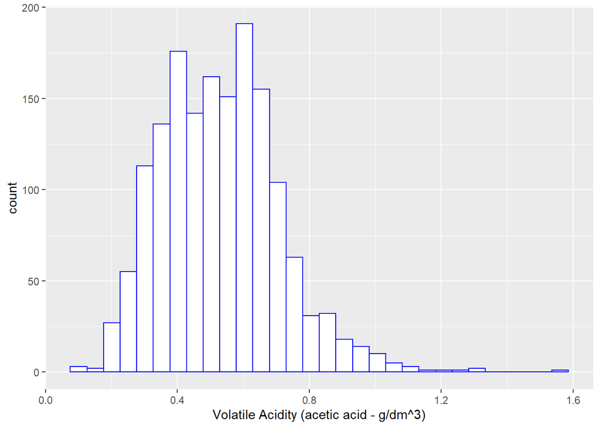

The volatile acidity is already looking slightly similar to the fixed acidity. It is looking like higher acidity wines are less avaialable.

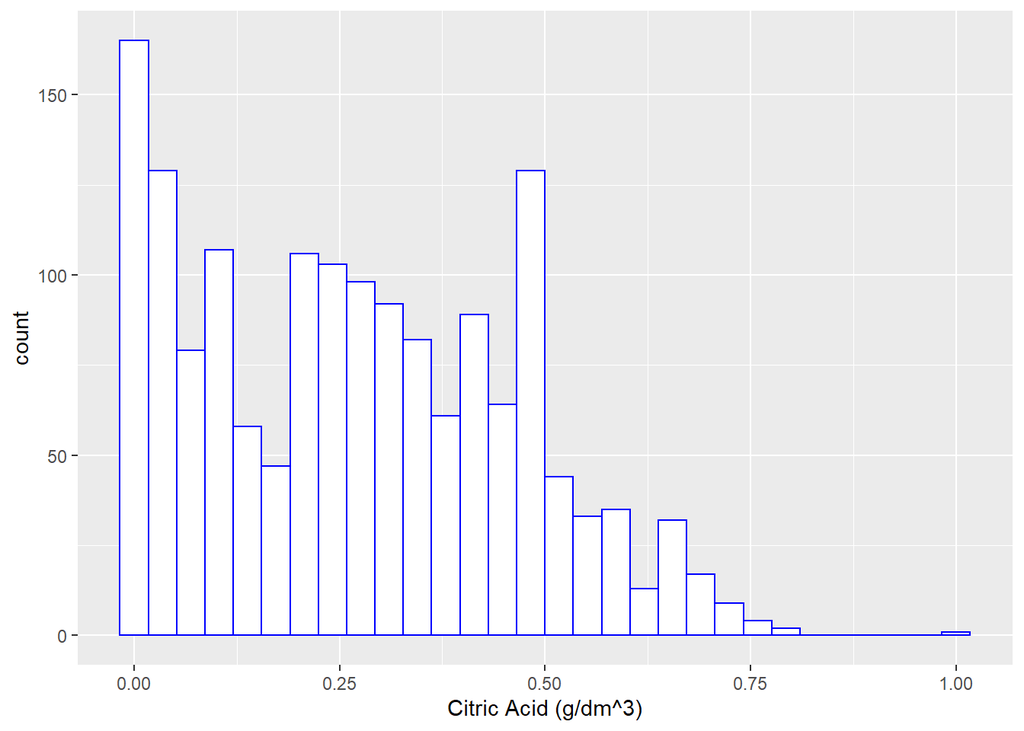

Once again, higher acid levels fall off. It may be the case that wines with more acid are of lower quality. It will be interesting to see how quality and acidity go together.

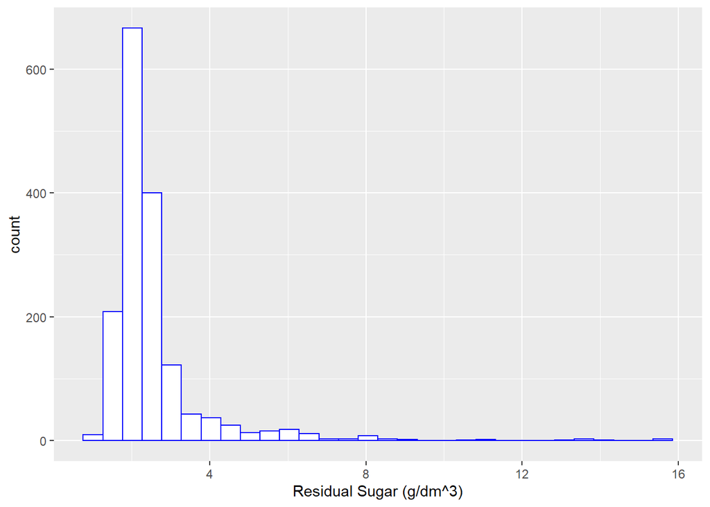

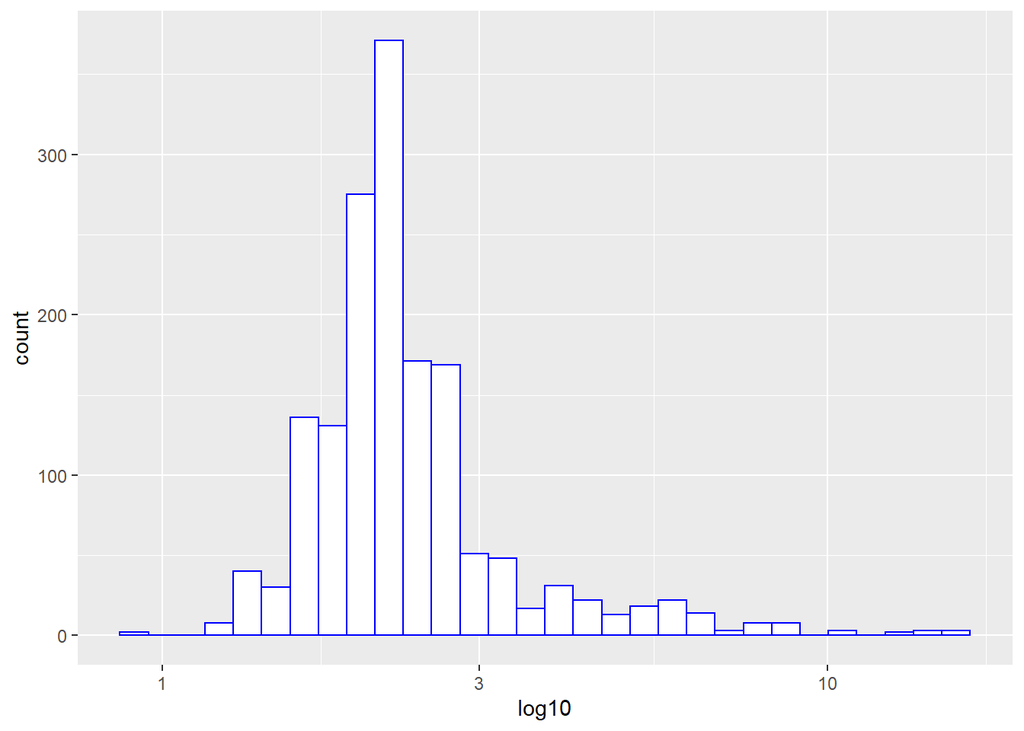

Most of the observations fall on the lower scale of residual sugar. This is between 0.5 and 6. So far, it seems that less is more when it comes to wine. The distirbution seems to have a slight skew to it.

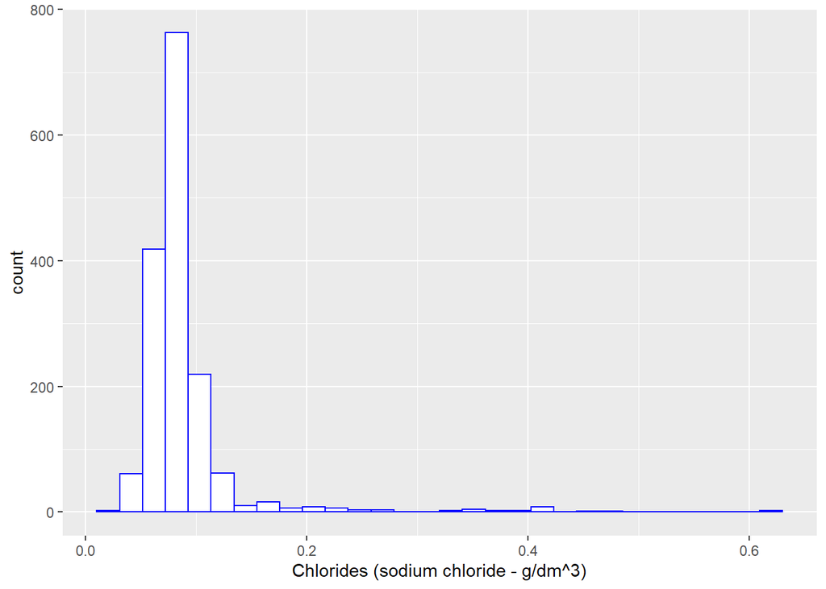

[figure not shown]

Chlorides seems to be staying the course so far. Most observations on the low end of the value range. The original histogram was over overdistributed, so I used a log10 scale to better see the distribution. The values end up being more normally distributed when I use this scale.

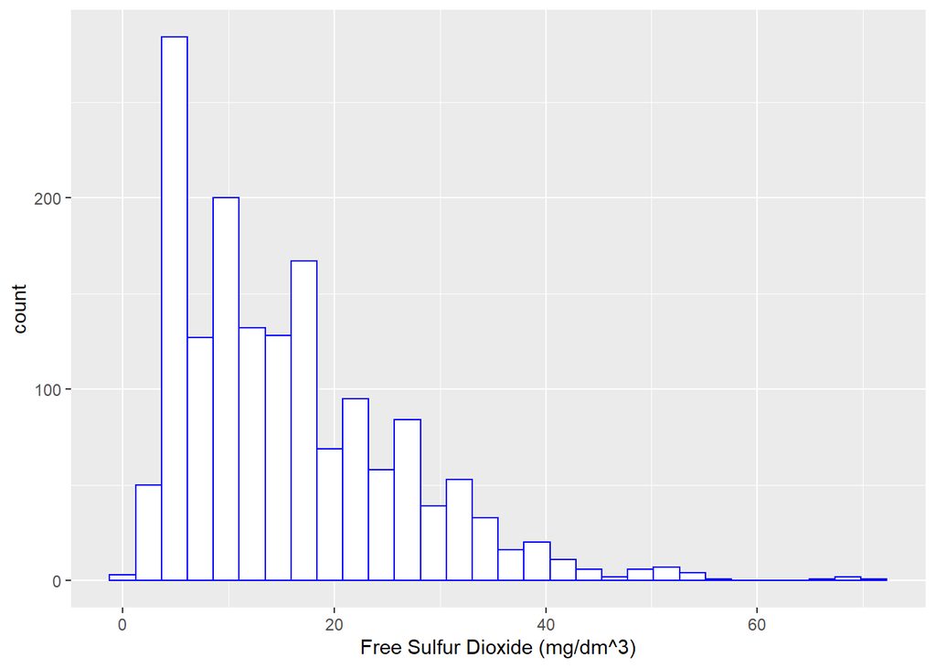

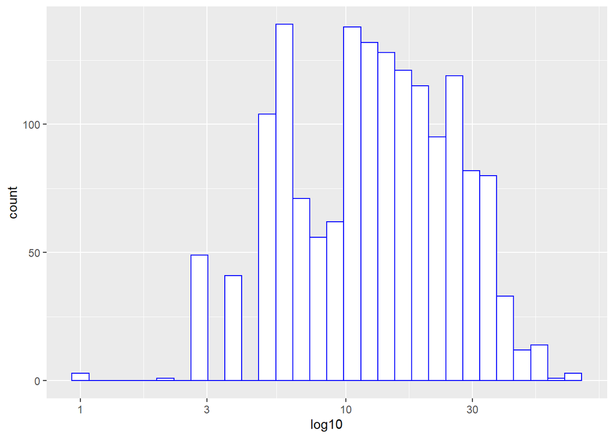

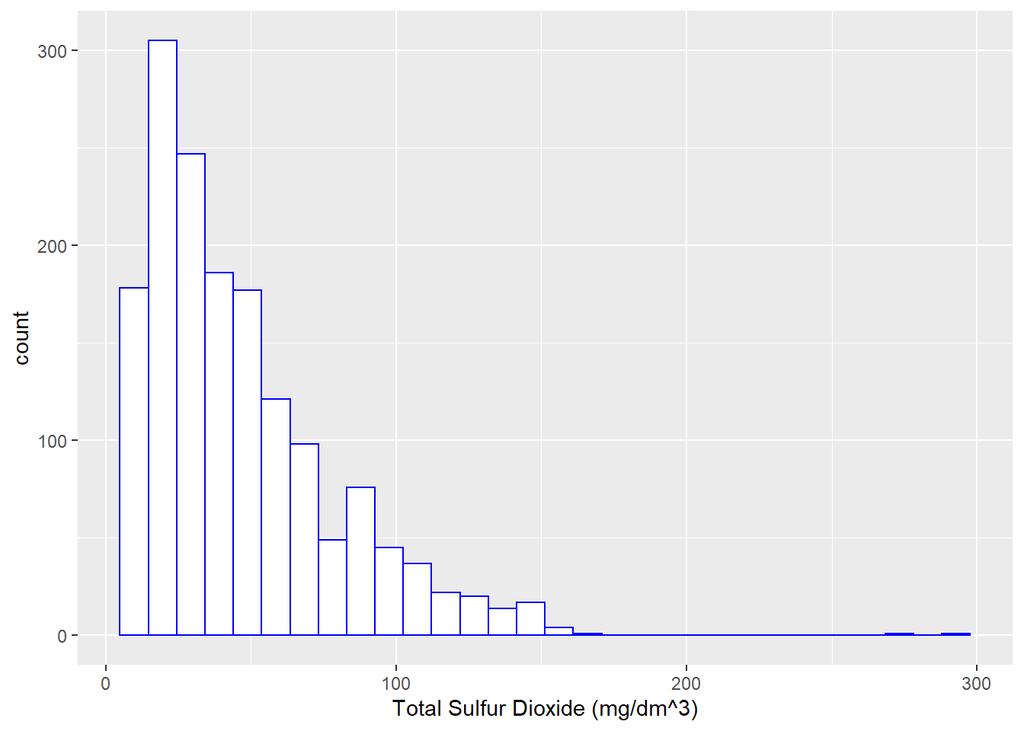

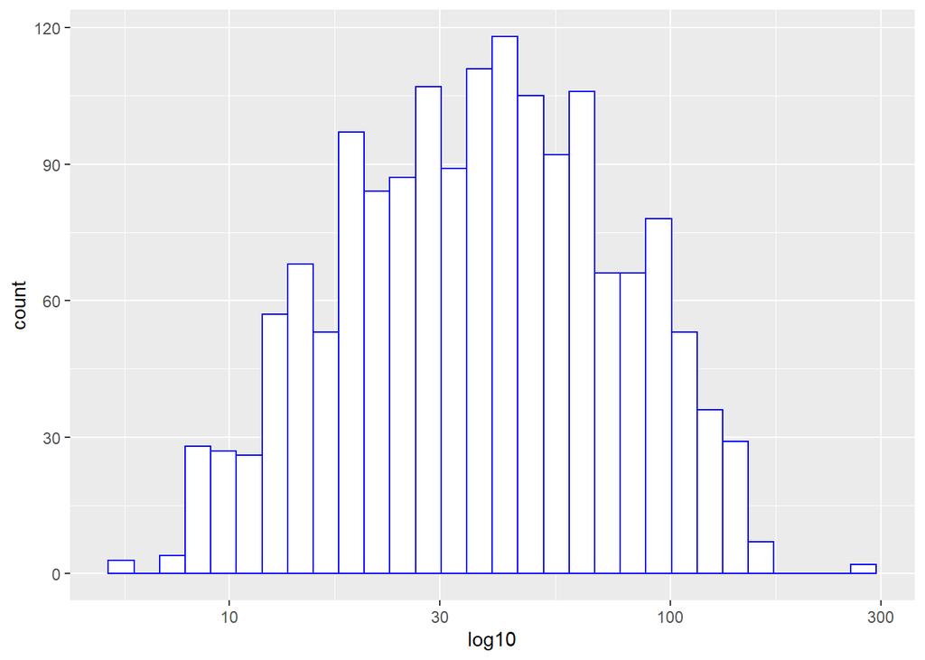

These two seem to go hand-in-hand. The reason being that free sulfur dioxide would be included in the total sulfur dioxide. As such, their distribution looks very similar. I wonder how free sulfur dioxide affects quality though up against total sulfur dioxide.

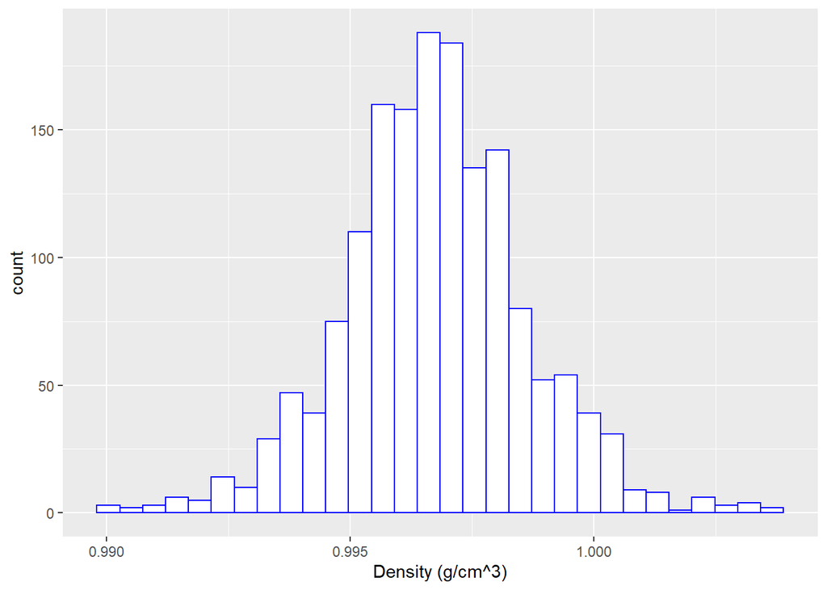

```
##    Min. 1st Qu.  Median    Mean 3rd Qu.    Max.
##  0.9901  0.9956  0.9968  0.9967  0.9978  1.0037
```

The density of red wine seems to have a very normal distribution. The median is .997 and the mean is .997. Most observations are very close to this number.

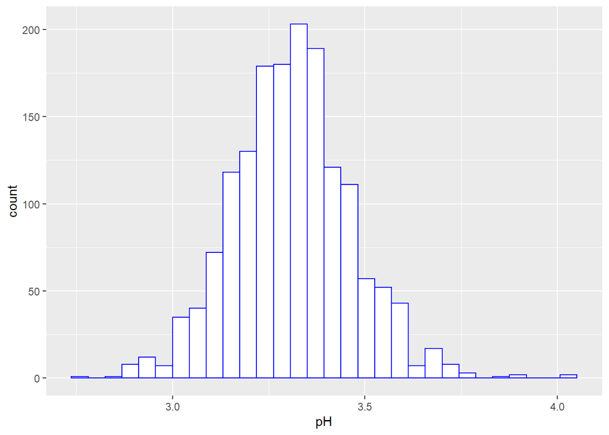

The pH of red wine also has a very normal distribution. I wonder if the pH will fall in line with the acidity levels in other variables.

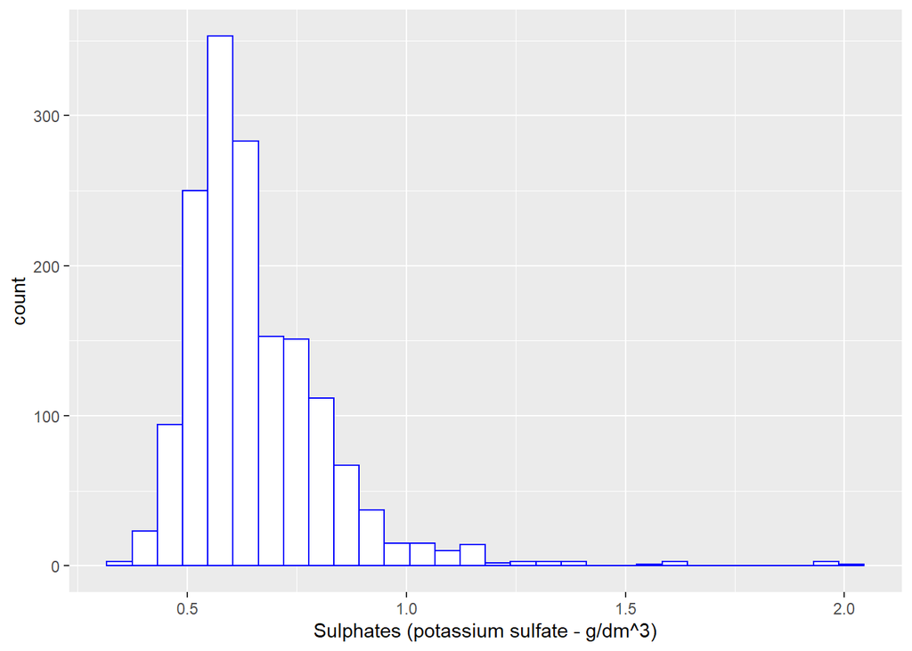

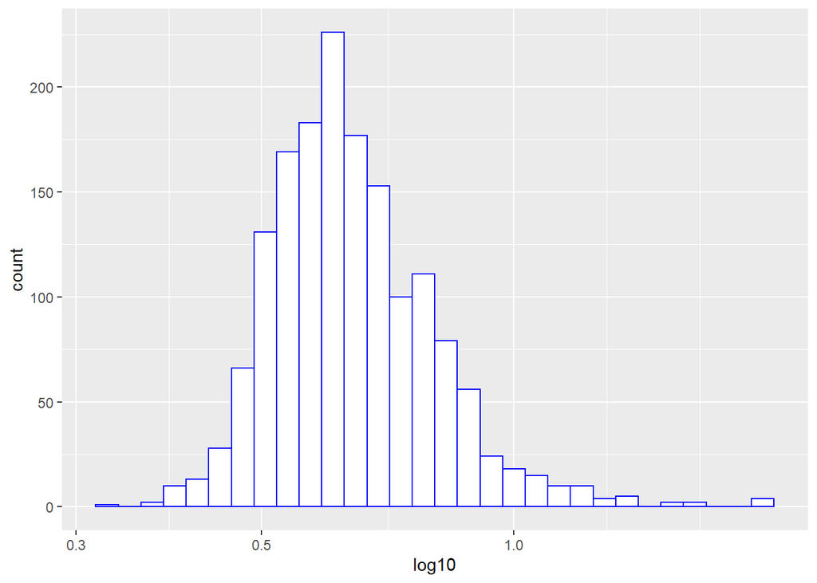

The original histogram suffers from overdistribution. When we transform using log10, we can see for the most part a normal distribution with a slight skew.

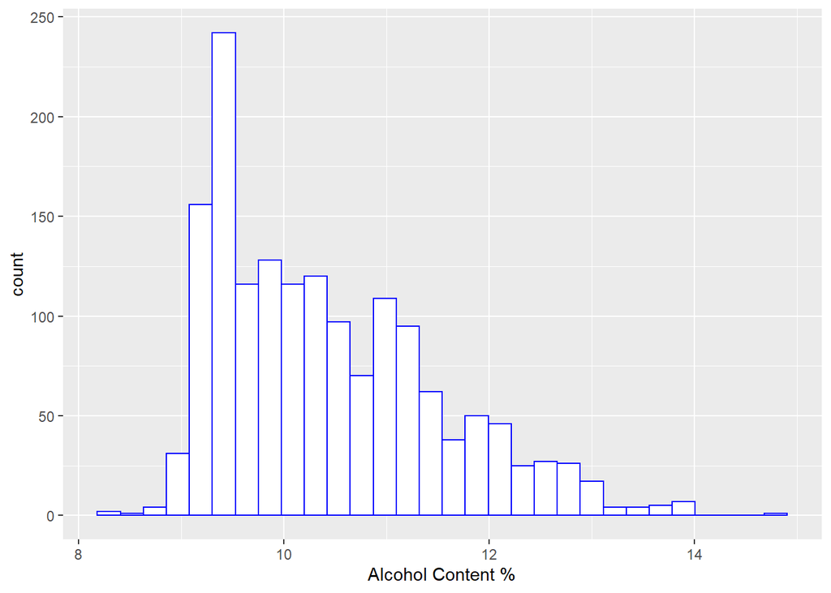

Most observations are around 9 to 10. I wonder if alcohol content has any thing to do with the other variables, such as if they tend to put more acid into a higher alcohol content wine.

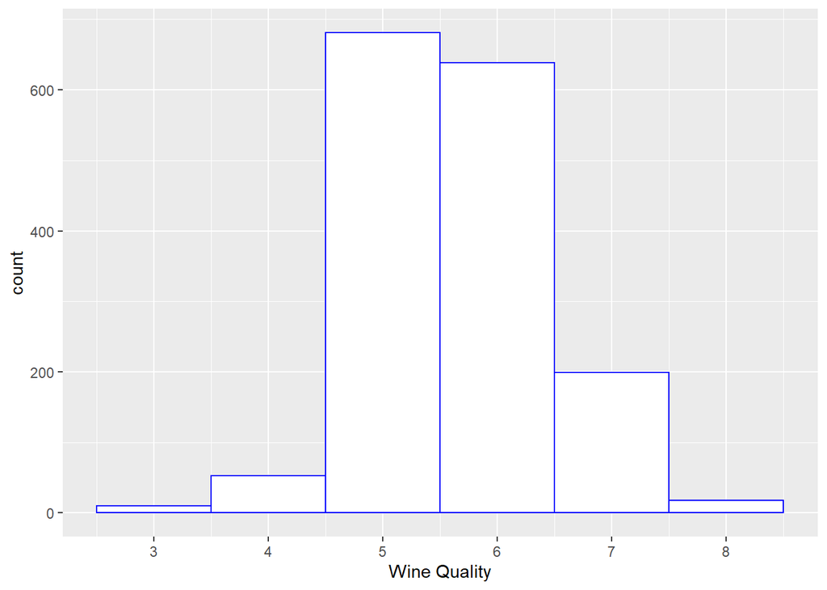

```
##    Min. 1st Qu.  Median    Mean 3rd Qu.    Max.
##   3.000   5.000   6.000   5.636   6.000   8.000
```

Here we have the quality of the wine. It is integer based as we can see from the histogram. The mean quality is 5.64 and the median quality is 6.

# Univariate Analysis

### What is the structure of your dataset?

There are 1599 different wine observations, and 13 variables. The variables are x, fixed acidity, volatile acidity, ciric acid, residual sugar, chlorides, free sulfur dioxide, total sulfur dioxide, density, pH, sulphates, alcohol, and quality. The x variable is an identifier sequence. Quality is an integer that is used to grade the alcohol. The rest of the variavlves are measurements. Some thoughts about the dataset:

- The median quality is 6.
- The mean quality is 5.64.
- The maximum alcohol content is 14.9, while the mean is 10.42.

### What is/are the main feature(s) of interest in your dataset?

The main features I am interested is how well everything correlates with quality. Since quality is the ‘judging’ factor in this, what makes a good wine? What makes a poor quality wine?

### What other features in the dataset do you think will help support your investigation into your feature(s) of interest?

I think that after I look at the correlation, I can see more places of interest to compare to quality and alcohol content of wines.

### Did you create any new variables from existing variables in the dataset?

Yes. I created a new variable new_quality. This is a factored version of the quality column. This will assist me in easier plotting later.

### Of the features you investigated, were there any unusual distributions? Did you perform any operations on the data to tidy, adjust, or change the form of the data? If so, why did you do this?

Several of the variables had long tails on them and strange distributions. I found it helpful to transform the data using log and I was able to get a better view of the distribution.

# Bivariate Plots Section

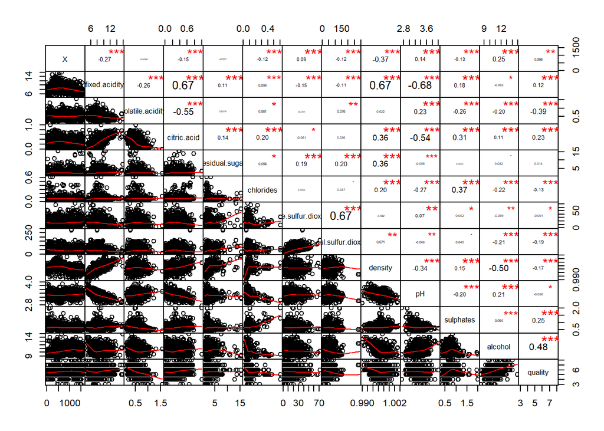

From the correlation chart, we can see quality has a strong positive correlation with alcohol, and a strong negative correlation with volatile acidity.

#### Alcohol and Quality

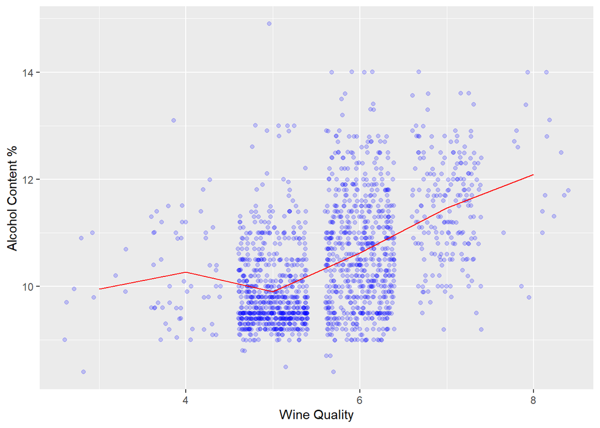

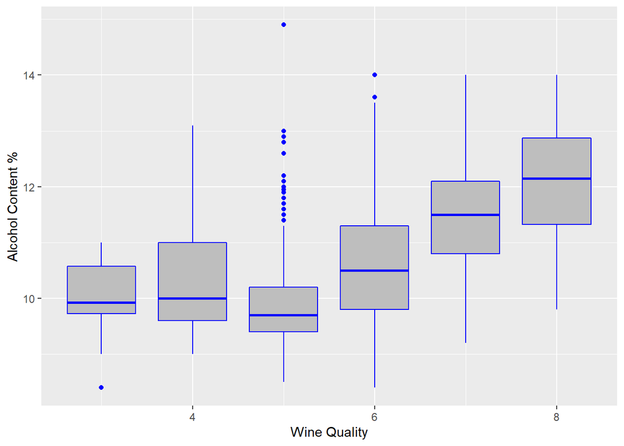

#### Correlation/Summary

```
## [1] 0.4761663
```

```
## rwine$quality: 3
##    Min. 1st Qu.  Median    Mean 3rd Qu.    Max.
##   8.400   9.725   9.925   9.955  10.575  11.000
## --------------------------------------------------------
## rwine$quality: 4
##    Min. 1st Qu.  Median    Mean 3rd Qu.    Max.
##    9.00    9.60   10.00   10.27   11.00   13.10
## --------------------------------------------------------
## rwine$quality: 5
##    Min. 1st Qu.  Median    Mean 3rd Qu.    Max.
##     8.5     9.4     9.7     9.9    10.2    14.9
## --------------------------------------------------------
## rwine$quality: 6
##    Min. 1st Qu.  Median    Mean 3rd Qu.    Max.
##    8.40    9.80   10.50   10.63   11.30   14.00
## --------------------------------------------------------
## rwine$quality: 7
##    Min. 1st Qu.  Median    Mean 3rd Qu.    Max.
##    9.20   10.80   11.50   11.47   12.10   14.00
## --------------------------------------------------------
## rwine$quality: 8
##    Min. 1st Qu.  Median    Mean 3rd Qu.    Max.
##    9.80   11.32   12.15   12.09   12.88   14.00
```

From looking at this correlation, we can see that the mean alcohol content of higher quality alcohols is higher. It is also capable of seeing that there are fewer high quality alcohols. Also, it can be seen that the average alcohol level is higher in the higher quality alcohols when looking at each quality rating’s mean.

#### Quality/Volatile Acidity

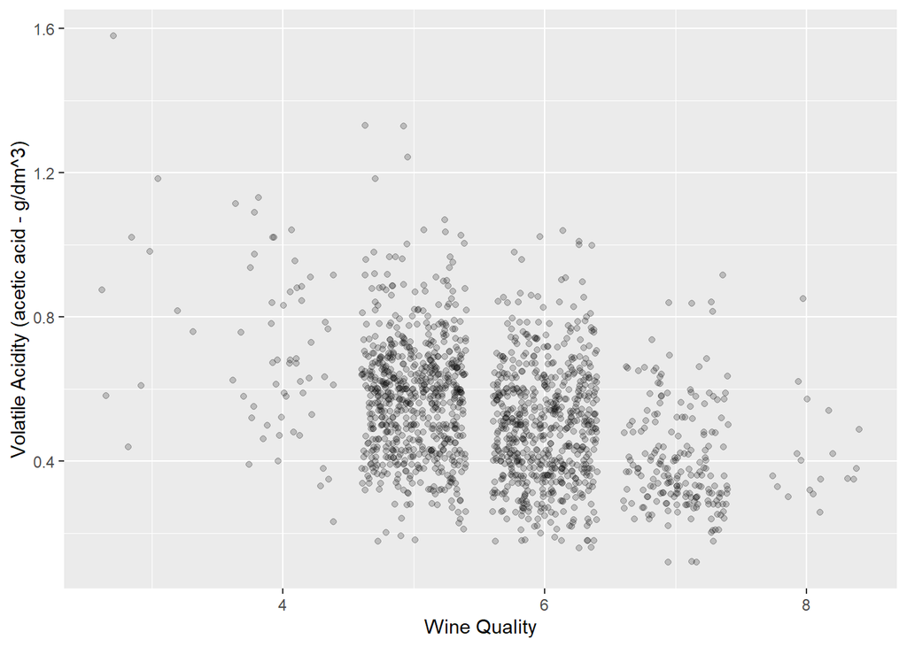

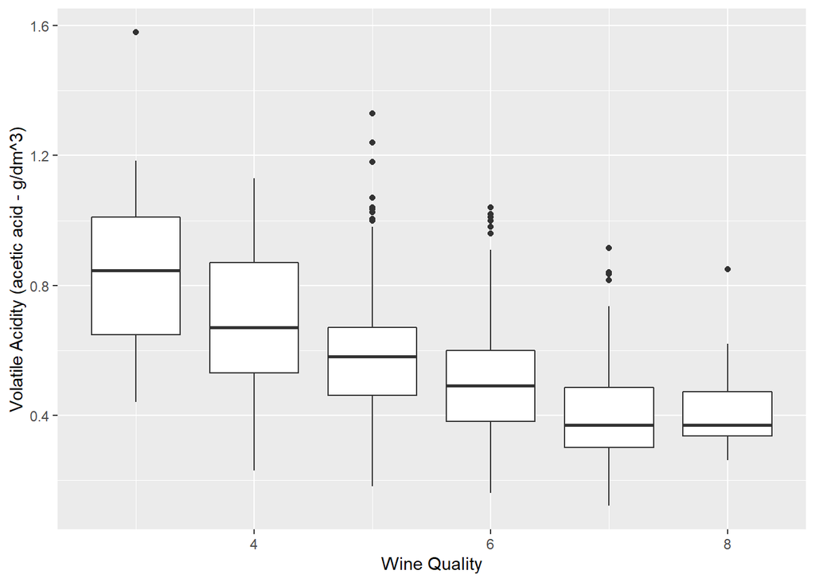

#### Correlation/Summary

```
## [1] -0.3905578
```

```
## rwine$quality: 3
##    Min. 1st Qu.  Median    Mean 3rd Qu.    Max.
##  0.4400  0.6475  0.8450  0.8845  1.0100  1.5800
## --------------------------------------------------------
## rwine$quality: 4
##    Min. 1st Qu.  Median    Mean 3rd Qu.    Max.
##   0.230   0.530   0.670   0.694   0.870   1.130
## --------------------------------------------------------
## rwine$quality: 5
##    Min. 1st Qu.  Median    Mean 3rd Qu.    Max.
##   0.180   0.460   0.580   0.577   0.670   1.330
## --------------------------------------------------------
## rwine$quality: 6
##    Min. 1st Qu.  Median    Mean 3rd Qu.    Max.
##  0.1600  0.3800  0.4900  0.4975  0.6000  1.0400
## --------------------------------------------------------
## rwine$quality: 7
##    Min. 1st Qu.  Median    Mean 3rd Qu.    Max.
##  0.1200  0.3000  0.3700  0.4039  0.4850  0.9150
## --------------------------------------------------------
## rwine$quality: 8
##    Min. 1st Qu.  Median    Mean 3rd Qu.    Max.
##  0.2600  0.3350  0.3700  0.4233  0.4725  0.8500
```

Looking at this correlation between quality and volatile acidity, it seems that usually high quality wines are of a lower acidity.

#### Alcohol/Density

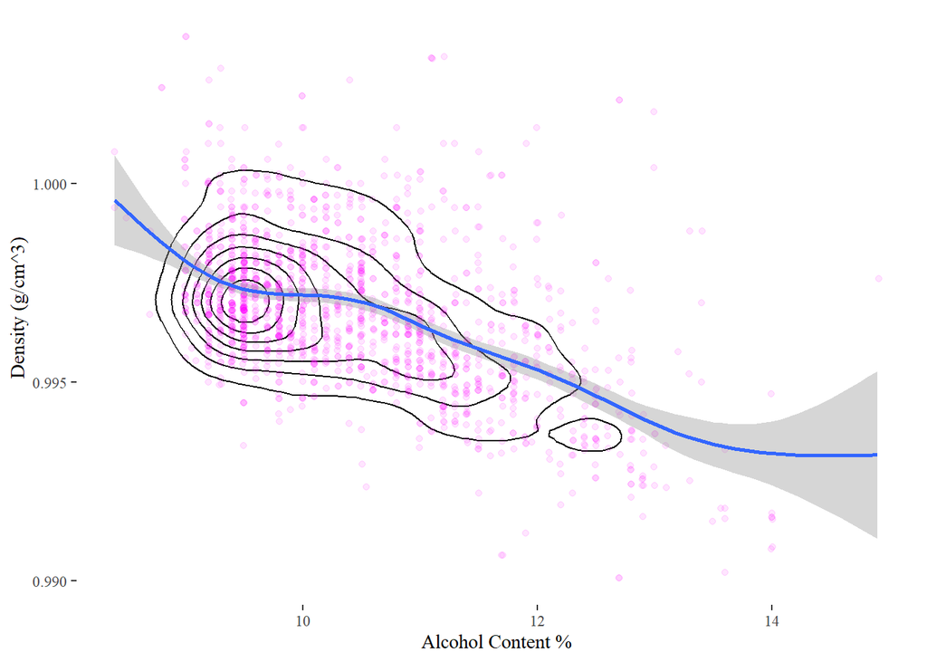

#### Correlation

```
## [1] -0.4961798
```

Looking at the graph, there is a strong negative correlation in density and alcohol. As the alcohol content gets higher, generally the density is reduced. It would also seem that most alcohols are of around 9.5 alcohol content.

#### Fixed Acidity/Density

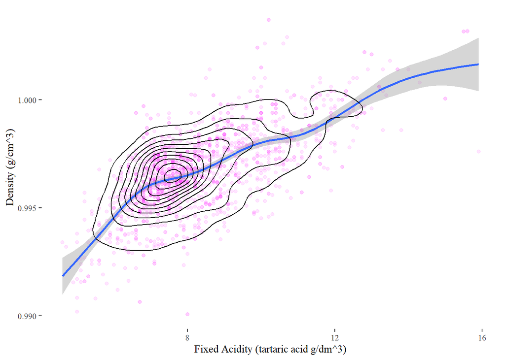

#### Correlation

```
## [1] 0.6680473
```

The plot shows that as acidity rises, generally so does density. There tend to be a strong positive correlation here. I think that it will be interesting to see how this looks when it is matched with other variabls in the multivariate analysis.

# Bivariate Analysis

### Talk about some of the relationships you observed in this part of the investigation. How did the feature(s) of interest vary with other features in the dataset?

Using the correlation plot, I was able to select out which relationships to observe. I selected out relationships with strong correlation. I am especially interested in alcohol vs quality. Since wine has such varying alcohol content and price, I wonder how this alcohol affects the quality, and if higher quality alcohols have higher or lower quality than others.

### Did you observe any interesting relationships between the other features (not the main feature(s) of interest)?

I am also intereted in exploring the volatile acidity levels and the fixed acidity levels. I was able to see correlation between the quality of the alcohol. Also the density of the alcohol seems to have an interesting correlation to alcohol content, which may also lead to discoveries about the density for different wine qualities.

### What was the strongest relationship you found?

The strongest correlation in the correlation plot was fixed acidity to pH. I would rather not use this one later, as pH is an acidity scale itself. The strongest correlation that I am interested in in density and fixed acidity.

# Multivariate Plots Section

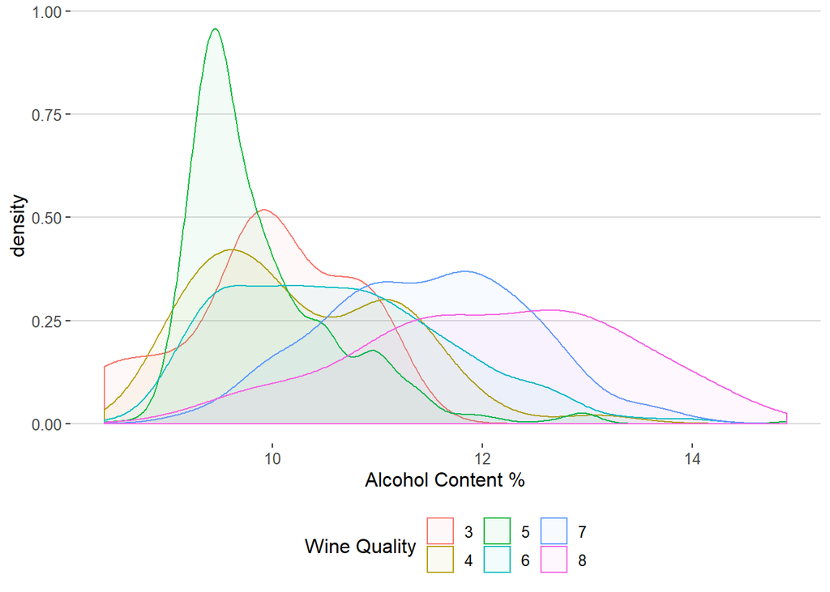

From this density plot, we can see how all of the different quality wines measure when when it coems to alcohol content. Quality 3’s, 4’s, and 5’s tend to stay below 12, while the higher quality ones have a better chance of being 10 and above.

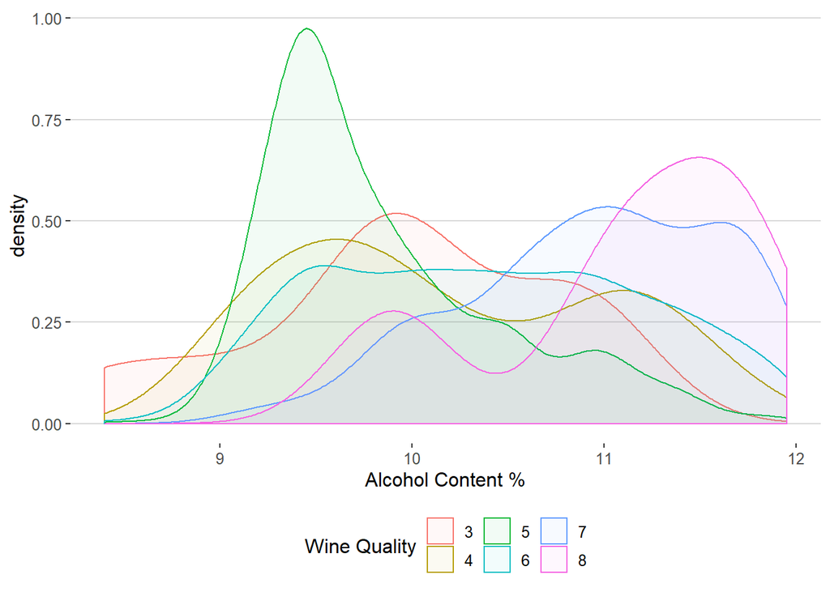

Creating two new data frames, I am able to zoom in to the areas of the plot that have alcohol greater than or equal to 12 and less than 12. Zooming in the the alcohol that is less than 12, we can see that most of the alcohols have a solid distribution acorss this range.

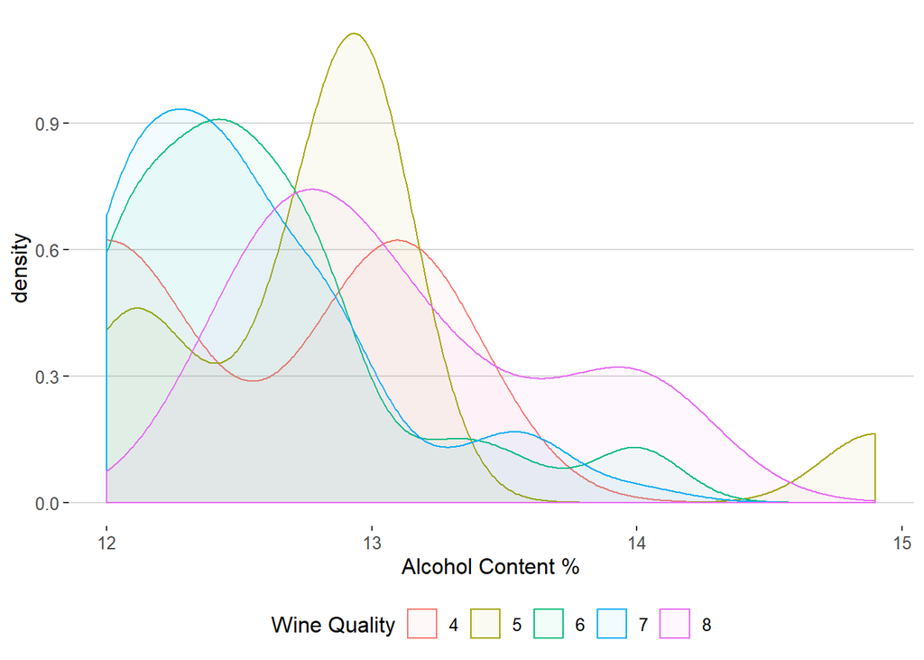

From zooming in to the alcohol above 12, we can actually see that quality 5 alcohols show up around 13 and 15. In the previous graphs this was very hard to see, but we can also see that quality 8 has the widest spread in the range.

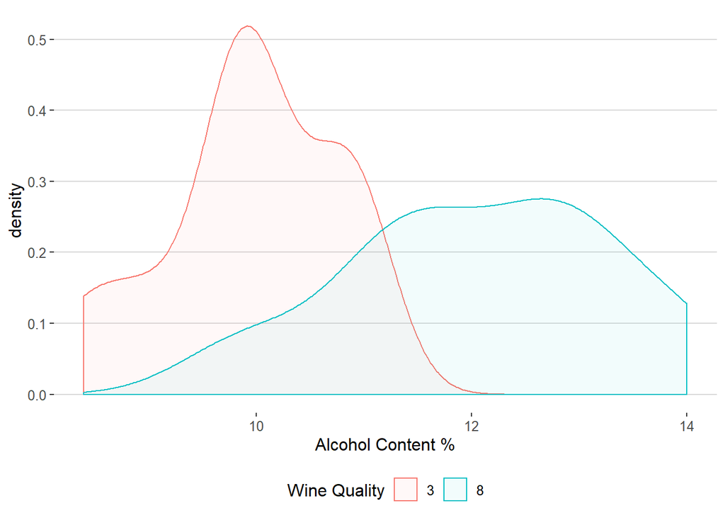

Now, when we look at a density plot for the lowest quality and the highest quality alcohol after creating the new data frame for this, we can see that the lowest quality tends to have more concentration on the lower end, and the higher quality tends to have more concentration on the higher end.

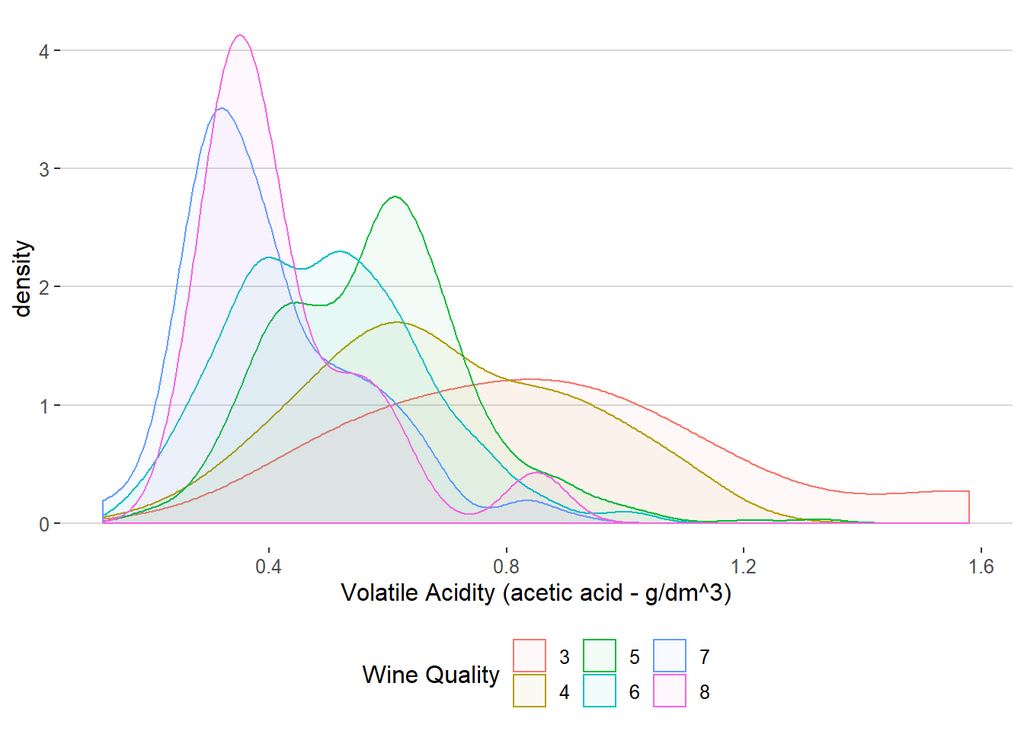

From this chart we can check out the density of volatile acidity based on the quality of the wine. From this chart, it would seem that most higher quality wines have a lower volatile acidity.

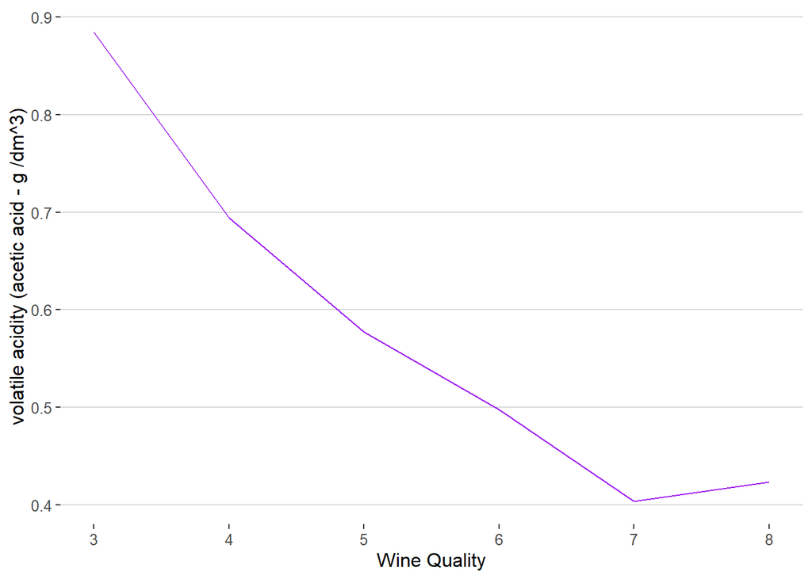

Here, looking at the volatile acidity density between qualities of wine, we can see that usually a higher quality wine has a lower volatile acidity. With the line graph, we can see a sharp decline in the mean volatile acidity based on the quality of wine.

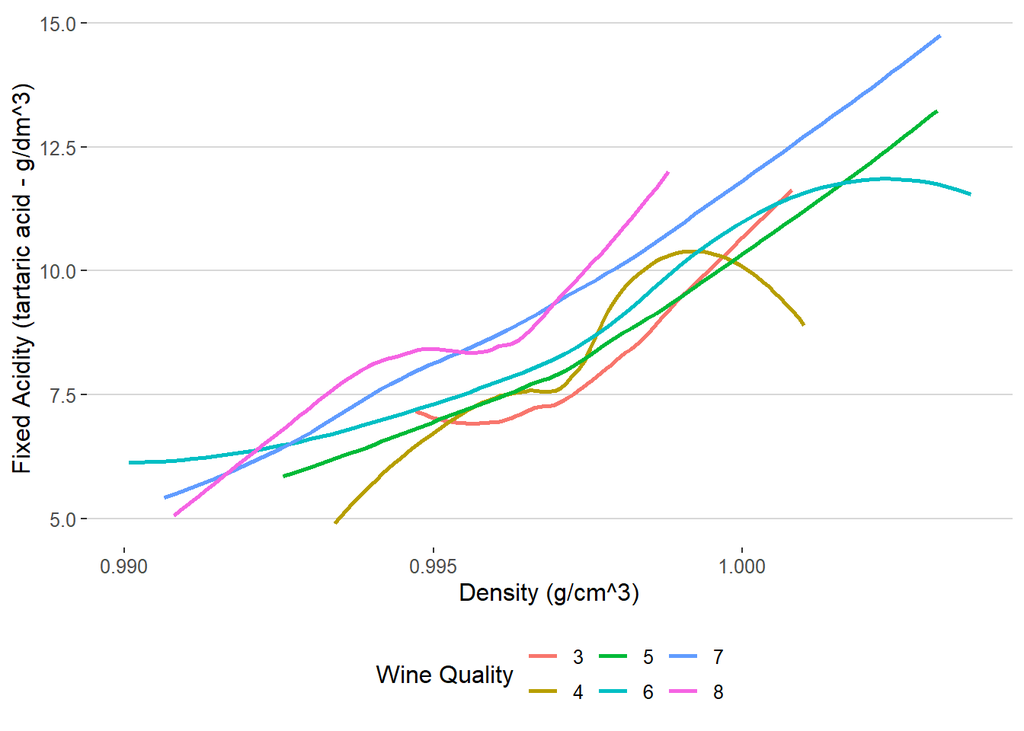

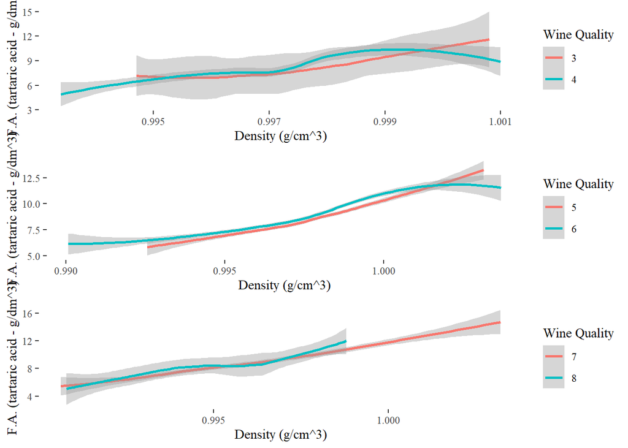

As we can see from these group of charts, the density and fixed acidity (F.A.) from the bivariate charts section holds true. As the density increases, the fixed acidity generally increases.